# SLU DSS Spring 2020

January 21, 2020

## Statistics in R

### Session #1

## Welcome!

The four sessions this semester will focus on applications of common statistical procedures using `R`:

Pre-requisites…

- Some background using `R`, `RStudio`, and `RMarkdown`, and knowledge of the `tidy` philosophy of data analysis (esp. `tidyverse` tools like `dplyr` for data wrangling and `ggplot2` for plotting)
- Working knowledge of univariate statistics, with a basic understanding of descriptive statistics, correlation, regression, and fundamentals of frequentist inference (i.e., NHST)

## Welcome!

Four sessions this semester:

- Session #1: Exploratory Data Analysis
- Session #2: Modeling Continuous Predictors
- Session #3: Modeling Categorical Predictors
- Session #4: Modern Approaches to Inference: The Bootstrap

Borrowing heavily from:

openintro.org  
moderndive.com

## Welcome!

**About me:**

Associate professor of Industrial & Organizational Psychology. BA from DePaul University; MA and Ph.D. from Wayne State University.

My research focuses on a variety of issues related to the aging workforce, including applications of lifespan development theories, wellbeing and work-longevity, and ageism/generationalism.

Interests in statistical and methodological advancements, particularly in meta-analysis, and emerging topics in open science practices.

Associate editor of the Journal of Vocational Behavior; My book, “Work Across the Lifespan” is available from Academic Press.

My website has more about me: http://cortrudolph.com

## Needed packages

- Let’s now load all the packages needed for this week.
- `ipak` codeblock available in the `RMarkdown` file:

```r
library(tidyverse)
library(skimr)
library(psych)
library(gridExtra)
library(kableExtra)
```

## Data for Examples

### `evals`

## Professor rating data

- We will use the `evals` dataset for the lecture demonstrations presented here.
- Data collected at the University of Texas in Austin
- Research question: “What factors can explain differences in instructor’s teaching evaluation scores?”
- Data on teaching evaluations (and related variables) from \(n = 463\) instructors.

## Professor rating data

- Let’s load the data, `select` only a subset of the variables:

```r
load(url("http://www.openintro.org/stat/data/evals.RData"))
evals <- evals %>%
  select(score, bty_avg, age)
```

## Exploratory data analysis

## Exploratory data analysis

- Before doing any kind of modeling or analysis, it is important to first perform an *exploratory data analysis*, or EDA
- Exploratory data analysis can, for example, give you a sense of the distribution of the data, whether there are outliers and/or missing values, and can inform how to build your model.
- There are many approaches to exploratory data analysis, here are three:
  1. Looking at the raw values, in a spreadsheet for example
  2. Computing summary statistics likes means, medians, and standard deviations
  3. Creating data visualizations

## Exploratory data analysis

- You can look at the raw values by running `View(evals)` in the console in `RStudio` to pop-up the spreadsheet-like viewer.
- Here, however, we present only a snapshot of 5 randomly chosen rows:

## Exploratory data analysis

Random Sample of 5 Instructors

| score | bty_avg | age |
| --- | --- | --- |
| 3.6 | 2.50 | 56 |
| 4.1 | 6.67 | 34 |
| 4.5 | 6.83 | 54 |
| 4.4 | 3.83 | 32 |
| 4.3 | 3.33 | 61 |

## Exploratory data analysis

- A full description of each of these variables can be found at [openintro.org](https://www.openintro.org/stat/data/?data=evals), let’s summarize what each of these variables represent
  1. `score`: Numerical variable of the average teaching score based on students’ evaluations between 1 and 5.
  2. `bty_avg`: Numerical variable of average “beauty” rating based on a panel of 6 students’ scores between 1 and 10.
  3. `age`: A numerical variable of chronological age.

## Exploratory data analysis

- Another way to look at the raw values is using the `tibble::glimpse()` function, which gives us a slightly different view of the data.
- We see `Observations: 463`, indicating that there are 463 observations in `evals`, each corresponding to a particular instructor at UT Austin.
- In other words, each row in the data frame `evals` corresponds to one of 463 instructors.

```r
glimpse(evals)
```

```
## Observations: 463
## Variables: 3
## $ score   <dbl> 4.7, 4.1, 3.9, 4.8, 4.6, 4.3, 2.8, 4.1, 3.4, 4.5, 3.8, 4…
## $ bty_avg <dbl> 5.00, 5.00, 5.00, 5.00, 3.00, 3.00, 3.00, 3.33, 3.33, 3.…
## $ age     <int> 36, 36, 36, 36, 59, 59, 59, 51, 51, 40, 40, 40, 40, 40, …
```

## Exploratory data analysis

- Since `score` and `bty_avg` are numerical, we can compute summary statistics about them such as the mean, median, and standard deviation.
- Let’s take `evals` and select only the two variables of interest for now.
- However, let’s instead pipe this into the `skim()` function from the `skimr` package.
- This function quickly “skims” the data

## Exploratory data analysis

```r
evals %>%
  select(score, bty_avg) %>%
  skim()
```

```
## Skim summary statistics
##  n obs: 463
##  n variables: 2
##
## ── Variable type:numeric ─────────────────────────────────────────────────────────
##  variable missing complete   n mean   sd   p0  p25  p50 p75 p100     hist
##   bty_avg       0      463 463 4.42 1.53 1.67 3.17 4.33 5.5 8.17 ▂▅▅▇▃▃▂▁
##     score       0      463 463 4.17 0.54 2.3  3.8  4.3  4.6 5    ▁▁▂▃▅▇▇▆
```

## Exploratory data analysis

- In this case, `skim()` returns:
  - `missing`: the number of missing values
  - `complete`: the number of non-missing or complete values
  - `n`: the total number of values
  - `mean`: the average
  - `sd`: the standard deviation

## Exploratory data analysis

- `p0`: the 0<sup>th</sup> percentile: the value at which 0% of observations are smaller than it. This is also known as the *minimum*
- `p25`: the 25<sup>th</sup> percentile: the value at which 25% of observations are smaller than it. This is also known as the *1<sup>st</sup>quartile*
- `p50`: the 50<sup>th</sup> percentile: the value at which 50% of observations are smaller than it. This is also know as the *2<sup>nd</sup>* quartile and more commonly the *median*
- `p75`: the 75<sup>th</sup> percentile: the value at which 75% of observations are smaller than it. This is also known as the *3<sup>rd</sup> quartile*
- `p100`: the 100<sup>th</sup> percentile: the value at which 100% of observations are smaller than it. This is also known as the *maximum*
- A quick snapshot of the `hist`ogram

## Exploratory data analysis

- From `skim()`, we get a sense of how the values in both variables are distributed.
- e.g., The mean teaching score was 4.17 out of 5 whereas the mean beauty score was 4.42 out of 10.
- e.g., The middle 50% of teaching scores were between 3.80 and 4.6 (the first and third quartiles)

## Exploratory data analysis

- The output provided by `skim()` is not very `tidy`, which makes it of limited use
- Another way to extract descriptive statistics is by using `psych::describe()`

```r
evals %>%
  select(score, bty_avg) %>%
  psych::describe() %>%
  select(n, mean, sd, median, min, max, range, skew, kurtosis) %>%
  kable() %>%
  kable_styling(full_width = FALSE)
```

|  | n | mean | sd | median | min | max | range | skew | kurtosis |
| --- | --- | --- | --- | --- | --- | --- | --- | --- | --- |
| score | 463 | 4.17 | 0.544 | 4.30 | 2.30 | 5.00 | 2.7 | -0.697 | 0.041 |
| bty_avg | 463 | 4.42 | 1.527 | 4.33 | 1.67 | 8.17 | 6.5 | 0.504 | -0.427 |

## Exploratory data analysis

- The `skim()` and `psych::describe()` functions only return what are called *univariate* summaries, i.e. summaries about single variables.
- If we are interested in considering the *relationship* between two numerical variables, it would be nice to have a summary statistic that simultaneously considers both variables.
- The *correlation coefficient* is a *bivariate* summary statistic that fits this bill.

## Exploratory data analysis

- A correlation coefficient can range between -1 and 1, and summarizes the *strength of the linear relationship between two numerical variables*:
  - -1 indicates a perfect *negative relationship*: as the value of one variable goes up, the value of the other variable tends to go down.
  - 0 indicates no relationship: the values of both variables go up/down independently of each other.
  - +1 indicates a perfect *positive relationship*: as the value of one variable goes up, the value of the other variable tends to go up as well.

## Exploratory data analysis

- The correlation coefficient is computed using the `cor()` function.

```r
evals %>%
  select(bty_avg, score) %>%
  cor() %>%
  kable() %>%
  kable_styling(full_width = FALSE)
```

|  | bty_avg | score |
| --- | --- | --- |
| bty_avg | 1.000 | 0.187 |
| score | 0.187 | 1.000 |

## Exploratory data analysis

- Here, the correlation coefficient of 0.187 indicates that the relationship between teaching evaluation score and beauty average is “weakly positive”

## Exploratory data analysis

- Let’s now proceed by visualizing these data.
- Since both the `score` and `bty_avg` variables are numerical, a scatterplot is an appropriate graph to visualize this data.
- Let’s do this using `geom_jitter()` to account for overplotting.

```r
ggplot(evals, aes(x = bty_avg, y = score)) +
       geom_jitter() +
       labs(x = "Beauty Score", y = "Teaching Score",
       title = "Relationship of teaching and beauty scores")
```

## Exploratory data analysis

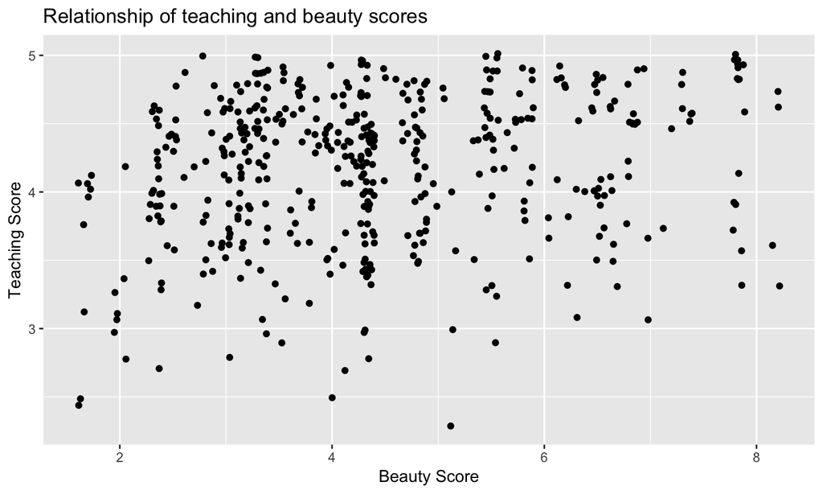

Instructor Evaluation Scores at UT Austin

## Exploratory data analysis

- Jittering adds a little random “noise” to each of the points to break up these ties between overlapping points: just enough so you can distinguish them, but not so much that the plot is overly altered.

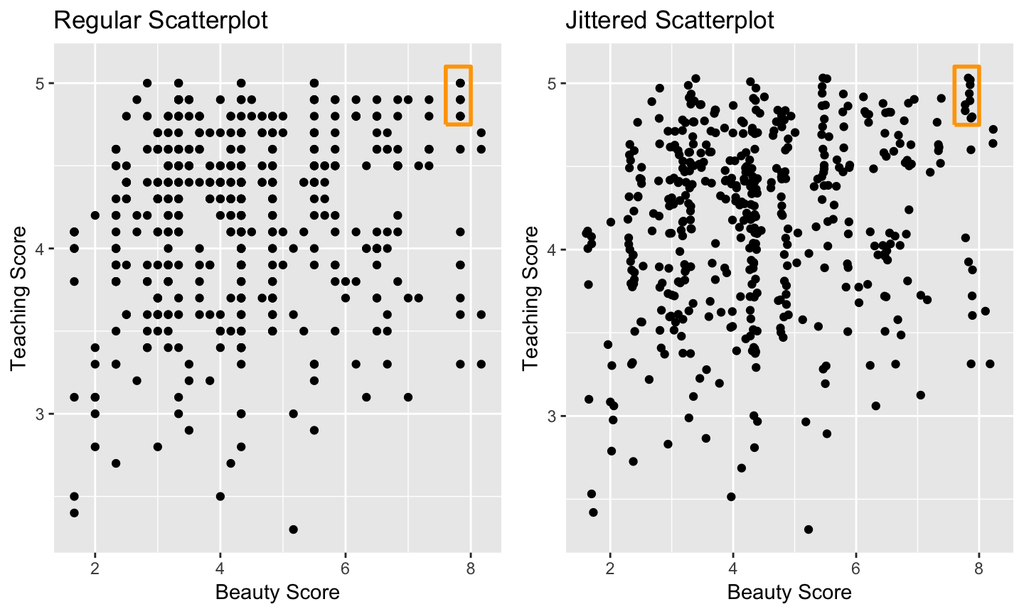

Comparing Regular and Jittered Scatterplots.

## Exploratory data analysis

- Observe the following:
  1. Most “beauty” scores lie between 2 and 8.
  2. Most teaching scores lie between 3 and 5.
- Recall our earlier computation of the correlation coefficient between these variables.
- Looking at the figure, it is not immediately apparent that these two variables are positively related.
- This is to be expected given the positive, but rather weak (i.e., close to 0), correlation coefficient of 0.187.

## Exploratory data analysis

- Going back to this scatterplot, let’s improve on it by adding a “regression line.”
- This is done by adding a new layer to the `ggplot` code that created the original figure: `+ geom_smooth(method = "lm", se = FALSE)`.
- A regression line is a “best fitting” line in that of all possible lines you could draw on this plot; it is “best” in terms of the “least squares” criteria.

```r
ggplot(evals, aes(x = bty_avg, y = score)) +
       geom_jitter() +
       labs(x = "Beauty Score", y = "Teaching Score",
                title = "Relationship of teaching and beauty scores") +
       geom_smooth(method = "lm", se = FALSE)
```

## Exploratory data analysis

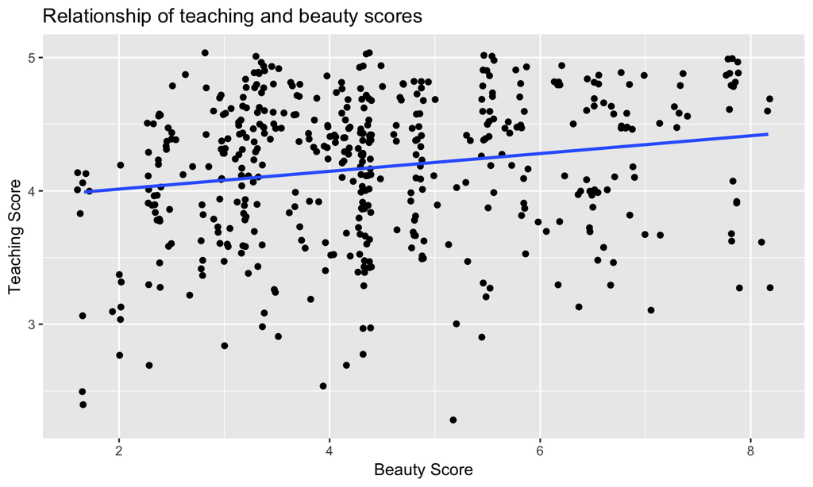

Regression Line

## Exploratory data analysis

- Here, the regression line is a nice visual summary of the relationship between these two numerical variables.
- The positive slope of the blue line is consistent with our observed correlation coefficient of 0.187 suggesting that there is a positive relationship between `score` and `bty_avg`.
- While the correlation coefficient is not equal to the slope of this line, they always have the same sign: positive or negative.

## Your Turn!

## CDC Data

The Behavioral Risk Factor Surveillance System (BRFSS) is an annual telephone survey of 350,000 people in the United States conducted by the CDC

Here, we will focus on a random sample of 20,000 people from the BRFSS survey conducted in 2000. While there are over 200 variables in this data set, for now, we will work with a small subset (i.e., just respondents height & weight):

First, we load the data:

```r
source("http://www.openintro.org/stat/data/cdc.R")
```

Then, select a random sample of \(n = 100\) respondents height & weight

```r
cdc_subset<-cdc %>%
  sample_n(100) %>%
  select(height, weight)
```

## View

```r
cdc_subset %>%
  sample_n(2) %>%
  knitr::kable(
    digits = 3,
    caption = "Random Sample of 2 Respondents",
    booktabs = TRUE) %>%
  kable_styling(full_width = F)
```

Random Sample of 2 Respondents

| height | weight |
| --- | --- |
| 74 | 215 |
| 71 | 155 |

## Summarize: Univariate Descriptives

```r
cdc_subset %>%
  skim()
```

```
## Skim summary statistics
##  n obs: 100
##  n variables: 2
##
## ── Variable type:integer ─────────────────────────────────────────────────────────
##  variable missing complete   n   mean    sd  p0    p25 p50 p75 p100
##    weight       0      100 100 171.43 37.34 107 146.25 166 195  290
##      hist
##  ▅▆▇▆▃▂▁▁
##
## ── Variable type:numeric ─────────────────────────────────────────────────────────
##  variable missing complete   n  mean   sd p0 p25 p50 p75 p100     hist
##    height       0      100 100 67.51 4.03 56  65  67  71   76 ▁▁▃▇▅▃▅▂
```

## Summarize: Bivariate Descriptives

```r
cdc_subset %>%
  cor()
```

```
##        height weight
## height  1.000  0.466
## weight  0.466  1.000
```

## Visualize

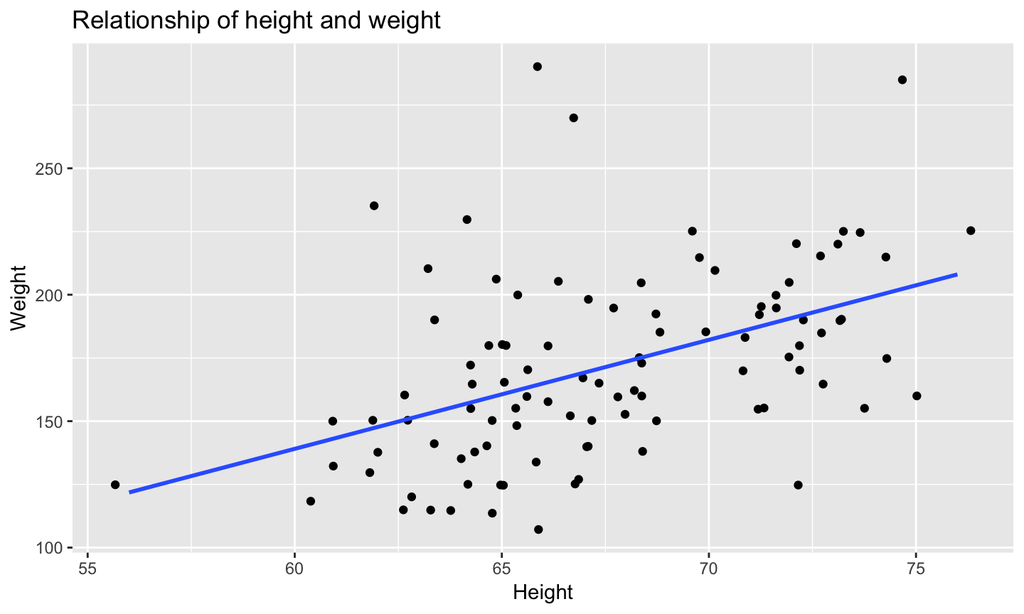

```r
ggplot(cdc_subset, aes(x = height, y = weight)) +
       geom_jitter() +
       labs(x = "Height", y = "Weight",
                title = "Relationship of height and weight") +
       geom_smooth(method = "lm", se = FALSE)
```